# thesis_2

Yu He

2023-04-04

# load libraries

```r
library(tidyverse)
library(haven)
library(caret)
library(cluster)
library(nnet)
library(broom)
library(pROC)
```

```r
library(rpart.plot)
```

Variable list:

Demographic Factors: a. Age b. Sex c. Grade d. Race (race4)

Food Allergy: a. Food Allergy (Qfoodallergy) - remove

Unintentional Injuries and Violence: a. Physical fights (Q17) b. Forced sexual activities (Q20) - remove c. Dating-related forced sexual activities (Q21) d. Bullying on school property (Q23) e. Suicidal thoughts (Q26)

Tobacco Use: a. Tried cigarette smoking (Q30)

Alcohol and Other Drug Use: a. Alcohol consumption (Q41) b. Marijuana use (Q47) c. Prescription pain medicine misuse (Q49) d. Cocaine use (Q50) e. Heroin use (Q52) f. Methamphetamine use (Q53) g. Needle use for injecting illegal drugs (Q56) - remove

Risky Sexual Behavior: a. Sexual intercourse (Q58) - remove b. Number of sexual partners (Q61) - remove c. Condom use (Q63) d. Sexual contact with different genders (Q65)

Cognitive and Health Factors: a. HIV testing (Q84) b. Asthma diagnosis (Q87) c. School grades (Q89)

Outcome Variable: a. STI testing other than HIV (Q85)

# Step 1, data proparing

## data import and process, save the processed sas7dbat data into csv file to improve R runnig time. Only run one time.

```r
# set path
setwd("~/Desktop/CU Spring 2023/master thesis II2/CU_2023_yu")

# load state data a_m
#df_a_m = read_sas("./data/sadc_2019_state_a_m.sas7bdat") %>%
#  janitor::clean_names() %>%
#  select(sitename, year, age, sex, grade, race4, bmi, qnothhpl, q85,
#         q17, q21, q23, q26, q30, q41, q47, q49, q50, q52, q53, q63, q65, q84, q87, q89
#         )

# save the data as a CSV file
# write.csv(df_a_m, "./data/df_a_m.csv", row.names = FALSE)

# load state data n_z
#df_n_z = read_sas("./data/sadc_2019_state_n_z.sas7bdat") %>%
#  janitor::clean_names() %>%
#    select(sitename, year, age, sex, grade, race4, bmi, qnothhpl, q85,
#         q17, q21, q23, q26, q30, q41, q47, q49, q50, q52, q53, q63, q65, q84, q87, q89)

# save the data as a CSV file
#write.csv(df_n_z, "./data/df_n_z.csv", row.names = FALSE)

# load school district data
#df_district = read_sas("./data/sadc_2019_district.sas7bdat") %>%
#  janitor::clean_names() %>%
#    select(sitename, year, age, sex, grade, race4, bmi, qnothhpl, q85,
#        q17, q21, q23, q26, q30, q41, q47, q49, q50, q52, q53, q63, q65, q84, q87, q89)

# save the data as a CSV file
#write.csv(df_district, "./data/df_district.csv", row.names = FALSE)
```

## import the processed data

```r
# load the processed  state data
df_part1 = read_csv("./data/df_a_m.csv")
df_part2 = read_csv("./data/df_n_z.csv")
# merge two state dataset
df_f_project = bind_rows(df_part1, df_part2)

# load the district dataset
df_district = read_csv("./data/df_district.csv")
```

## create new variables and data cleaning

```r
# create new variables for state data
df_fit_state <-
  df_f_project %>%
  filter(year == 2019) %>%
  mutate(
  across(c("sex", "age", "grade", "race4", "qnothhpl"), as.factor),
  year = as.character(year)
  ) %>%
  mutate_at(vars(starts_with("q")), as.factor) %>%
  filter(q85 %in% c(1, 2, 3)) %>%
  na.omit()


df_fit_district <-
  df_district %>%
  filter(year == 2019) %>%
    mutate(
  across(c("sex", "age", "grade", "race4", "qnothhpl"), as.factor),
  year = as.character(year)
  ) %>%
  mutate_at(vars(starts_with("q")), as.factor) %>%
  filter(q85 %in% c(1, 2, 3)) %>%
  na.omit()

df_fit_state %>%
  group_by(sitename) %>%
  summarize(
    n_obs = n()
  )
```

```
## # A tibble: 12 × 2
##    sitename            n_obs
##    <chr>               <int>
##  1 Alabama (AL)          308
##  2 Arkansas (AR)         303
##  3 Illinois (IL)         398
##  4 Iowa (IA)             234
##  5 Kentucky (KY)         313
##  6 Michigan (MI)         581
##  7 Mississippi (MS)      263
##  8 Nebraska (NE)         201
##  9 Oklahoma (OK)         347
## 10 Pennsylvania (PA)     440
## 11 South Carolina (SC)   125
## 12 West Virginia (WV)    284
```

```r
df_fit_district %>%
  group_by(sitename) %>%
  summarize(
    n_obs = n()
  )
```

```
## # A tibble: 15 × 2
##    sitename                     n_obs
##    <chr>                        <int>
##  1 Broward County, FL (FT)        167
##  2 Chicago, IL (CH)               157
##  3 Eaton Consortium, MI (EA)      129
##  4 Fort Worth, TX (FW)            237
##  5 Genesee Consortium, MI (GE)    166
##  6 Hillsborough County, FL (HL)   247
##  7 Los Angeles, CA (LO)           109
##  8 Newark, NJ (NW)                140
##  9 Orange County, FL (OL)         123
## 10 Palm Beach County, FL (PB)     305
## 11 Pasco County, FL (PS)          197
## 12 Philadelphia, PA (PH)          171
## 13 Portland, OR (PO)              213
## 14 San Francisco, CA (SF)         203
## 15 Shelby County, TN (ST)         159
```

```r
summary(df_fit_district)
```

```
##    sitename             year           age     sex      grade    race4
##  Length:2723        Length:2723        1:  0   1:1481   1: 275   1: 816
##  Class :character   Class :character   2:  0   2:1242   2: 609   2: 579
##  Mode  :character   Mode  :character   3:111            3: 822   3:1033
##                                        4:420            4:1017   4: 295
##                                        5:728
##                                        6:943
##                                        7:521
##       bmi        qnothhpl q85           q17       q21      q23      q26
##  Min.   :13.58   1: 732   1: 713   1      :1905   1: 239   1: 410   1: 647
##  1st Qu.:20.38   2:1991   2:1843   2      : 344   2:2292   2:2313   2:2076
##  Median :22.49            3: 167   3      : 296   3:  91
##  Mean   :23.64                     4      :  89   4:  55
##  3rd Qu.:25.72                     8      :  38   5:  17
##  Max.   :58.89                     5      :  28   6:  29
##                                    (Other):  23
##  q30      q41      q47      q49      q50      q52      q53      q63
##  1: 774   1:1531   1:1573   1:2190   1:2571   1:2695   1:2682   1:   0
##  2:1949   2: 589   2: 372   2: 230   2:  81   2:  12   2:  20   2:1508
##           3: 340   3: 292   3: 136   3:  48   3:   3   3:   5   3:1215
##           4: 154   4: 162   4:  77   4:   8   4:   6   4:   1
##           5:  83   5: 144   5:  30   5:   6   5:   1   5:   7
##           6:  15   6: 180   6:  60   6:   9   6:   6   6:   8
##           7:  11
##  q65      q84      q87      q89
##  1:   0   1: 705   1: 683   1: 871
##  2:1233   2:1738   2:1934   2:1062
##  3:1223   3: 280   3: 106   3: 518
##  4: 267                     4: 104
##                             5:  50
##                             6:  14
##                             7: 104
```

```r
summary(df_fit_state)
```

```
##    sitename             year           age      sex      grade    race4
##  Length:3797        Length:3797        1:   0   1:2023   1: 500   1:2392
##  Class :character   Class :character   2:   5   2:1774   2: 845   2: 545
##  Mode  :character   Mode  :character   3: 130            3:1220   3: 550
##                                        4: 614            4:1232   4: 310
##                                        5:1011
##                                        6:1251
##                                        7: 786
##       bmi        qnothhpl q85           q17       q21      q23      q26
##  Min.   :13.25   1:1358   1: 768   1      :2681   1: 303   1: 841   1: 946
##  1st Qu.:20.62   2:2439   2:2820   2      : 502   2:3231   2:2956   2:2851
##  Median :22.89            3: 209   3      : 391   3: 112
##  Mean   :24.20                     4      :  96   4:  90
##  3rd Qu.:26.51                     8      :  60   5:  29
##  Max.   :54.40                     5      :  38   6:  32
##                                    (Other):  29
##  q30      q41      q47      q49      q50      q52      q53      q63
##  1:1630   1:2029   1:2469   1:3032   1:3601   1:3753   1:3730   1:   0
##  2:2167   2: 873   2: 426   2: 323   2: 101   2:  22   2:  27   2:1999
##           3: 443   3: 312   3: 195   3:  44   3:   3   3:  10   3:1798
##           4: 247   4: 193   4:  97   4:  24   4:   2   4:   7
##           5: 148   5: 145   5:  69   5:   6   5:   2   5:   3
##           6:  30   6: 252   6:  81   6:  21   6:  15   6:  20
##           7:  27
##  q65      q84      q87      q89
##  1:   0   1: 739   1: 945   1:1426
##  2:1741   2:2676   2:2718   2:1395
##  3:1761   3: 382   3: 134   3: 667
##  4: 295                     4: 147
##                             5:  50
##                             6:  11
##                             7: 101
```

```r
# Check for missing values
missing_vals_1 <- is.na(df_fit_district)

# Count the number of missing values in each column
colSums(missing_vals_1)
```

```
## sitename     year      age      sex    grade    race4      bmi qnothhpl
##        0        0        0        0        0        0        0        0
##      q85      q17      q21      q23      q26      q30      q41      q47
##        0        0        0        0        0        0        0        0
##      q49      q50      q52      q53      q63      q65      q84      q87
##        0        0        0        0        0        0        0        0
##      q89
##        0
```

```r
# Check for missing values
missing_vals_2 <- is.na(df_fit_state)

# Count the number of missing values in each column
colSums(missing_vals_2)
```

```
## sitename     year      age      sex    grade    race4      bmi qnothhpl
##        0        0        0        0        0        0        0        0
##      q85      q17      q21      q23      q26      q30      q41      q47
##        0        0        0        0        0        0        0        0
##      q49      q50      q52      q53      q63      q65      q84      q87
##        0        0        0        0        0        0        0        0
##      q89
##        0
```

# Step 2, fit the multinominal logistic regression

## first try to fit on the whole data, ignore clustered by sitename for now.

```r
df_district_lr <- df_fit_district %>%
  select(-sitename) %>%
  select(-year)

# Fit the model using the cleaned dataset
model <- multinom(q85 ~ ., data = df_district_lr)
summary_model = summary(model)
# Get a tidy version of the model output
tidy_model <- tidy(model)
# Set the significance level
alpha <- 0.05

# Find significant variables based on the p-value
significant_vars <- tidy_model$p.value < alpha

# Print the significant variables
significant_results <- tidy_model[significant_vars, ]
print(significant_results)
```

```
## # A tibble: 39 × 6
##    y.level term        estimate std.error statistic      p.value
##    <chr>   <chr>          <dbl>     <dbl>     <dbl>        <dbl>
##  1 2       (Intercept)   -0.578    0.270      -2.14  0.0324
##  2 <NA>    <NA>          NA       NA          NA    NA
##  3 2       race42        -0.619    0.188      -3.29  0.00101
##  4 2       race43        -0.368    0.160      -2.31  0.0211
##  5 2       qnothhpl2      0.759    0.143       5.30  0.000000117
##  6 2       q178          -1.35     0.529      -2.55  0.0107
##  7 2       q492           0.516    0.242       2.13  0.0329
##  8 2       q525          -0.876    0.0196    -44.6   0
##  9 2       q534           2.92     0.0176    166.    0
## 10 2       q633          -0.347    0.148      -2.35  0.0188
## # … with 29 more rows
```

## fit multinominal logistic regression for every disctrict

```r
# Define a function to fit the multinom model for each site
fit_multinom_for_site_d <- function(site, data) {
  df_site <- data %>%
    filter(sitename == site) %>%
    select(-sitename) %>%
    select(-year)

  # Fit the model using the cleaned dataset
  model <- multinom(q85 ~ ., data = df_site)

  summary_model <- summary(model)
  tidy_model <- tidy(model)

  # Set the significance level
  alpha <- 0.05

  # Find significant variables based on the p-value
  significant_vars <- tidy_model$p.value < alpha

  # Print the significant variables
  significant_results <- tidy_model[significant_vars, ]
  return(list(site = site, significant_results = significant_results))
}

# Get the unique site names from the dataset
unique_sites_d <- unique(df_fit_district$sitename)

# Fit the multinom model for each site
models_by_site <- lapply(unique_sites_d, fit_multinom_for_site_d, data = df_fit_district)
# Display the results
print(models_by_site)
```

```
## [[1]]
## [[1]]$site
## [1] "Chicago, IL (CH)"
##
## [[1]]$significant_results
## # A tibble: 69 × 6
##    y.level term      estimate     std.error    statistic p.value
##    <chr>   <chr>        <dbl>         <dbl>        <dbl>   <dbl>
##  1 2       bmi         -0.429  0.173               -2.47  0.0133
##  2 2       qnothhpl2    5.18   2.19                 2.36  0.0181
##  3 2       q175        10.1    0.00171           5930.    0
##  4 2       q176         4.39   0.0000984        44633.    0
##  5 2       q177       -20.8    0.000000820  -25325147.    0
##  6 <NA>    <NA>        NA     NA                   NA    NA
##  7 2       q215        28.0    0.0000000507 551167172.    0
##  8 2       q216        -1.76   0.0144            -123.    0
##  9 2       q232       -11.3    4.93                -2.30  0.0215
## 10 2       q415        10.1    4.80                 2.09  0.0364
## # … with 59 more rows
##
##
## [[2]]
## [[2]]$site
## [1] "Eaton Consortium, MI (EA)"
##
## [[2]]$significant_results
## # A tibble: 71 × 6
##    y.level term  estimate std.error statistic   p.value
##    <chr>   <chr>    <dbl>     <dbl>     <dbl>     <dbl>
##  1 <NA>    <NA>     NA    NA         NA       NA
##  2 2       age3    -21.0   1.48e+ 0  -1.42e 1  1.02e-45
##  3 <NA>    <NA>     NA    NA         NA       NA
##  4 2       q178   -187.    7.09e- 9  -2.64e10  0
##  5 2       q213   -154.    1.49e-11  -1.03e13  0
##  6 2       q214     -3.04  1.35e- 8  -2.25e 8  0
##  7 2       q215     -1.11  6.96e-40  -1.59e39  0
##  8 2       q216    -52.6   9.64e-20  -5.46e20  0
##  9 2       q414    111.    1.25e-22   8.91e23  0
## 10 2       q415   -249.    6.19e- 1  -4.03e 2  0
## # … with 61 more rows
```

[output cut: 258 more lines]

```
## [[15]]$significant_results
## # A tibble: 59 × 6
##    y.level term  estimate   std.error statistic p.value
##    <chr>   <chr>    <dbl>       <dbl>     <dbl>   <dbl>
##  1 <NA>    <NA>      NA   NA                NA       NA
##  2 <NA>    <NA>      NA   NA                NA       NA
##  3 <NA>    <NA>      NA   NA                NA       NA
##  4 <NA>    <NA>      NA   NA                NA       NA
##  5 2       q216     -17.8  0.000298     -59819.       0
##  6 <NA>    <NA>      NA   NA                NA       NA
##  7 <NA>    <NA>      NA   NA                NA       NA
##  8 <NA>    <NA>      NA   NA                NA       NA
##  9 2       q496      25.2  0.00000157 16030281.       0
## 10 2       q502      33.4  0.0425          785.       0
## # … with 49 more rows
```

## fit multinominal logistic regression for every state

```r
# Define a function to fit the multinom model for each site
fit_multinom_for_site_s <- function(site, data) {
  df_site <- data %>%
    filter(sitename == site) %>%
    select(-sitename) %>%
    select(-year)

  # Fit the model using the cleaned dataset
  model <- multinom(q85 ~ ., data = df_site)

  summary_model <- summary(model)
  tidy_model <- tidy(model)

  # Set the significance level
  alpha <- 0.05

  # Find significant variables based on the p-value
  significant_vars <- tidy_model$p.value < alpha

  # Print the significant variables
  significant_results <- tidy_model[significant_vars, ]
  return(list(site = site, significant_results = significant_results))
}

# Get the unique site names from the dataset
unique_sites_s <- unique(df_fit_state$sitename)

# Fit the multinom model for each site
models_by_site <- lapply(unique_sites_s, fit_multinom_for_site_s, data = df_fit_state)
# Display the results
print(models_by_site)
```

```
## [[1]]
## [[1]]$site
## [1] "Alabama (AL)"
##
## [[1]]$significant_results
## # A tibble: 111 × 6
##    y.level term        estimate std.error statistic   p.value
##    <chr>   <chr>          <dbl>     <dbl>     <dbl>     <dbl>
##  1 2       (Intercept)    14.1   1.90e+ 0   7.42e 0 1.14e- 13
##  2 2       age2          181.    1.20e- 9   1.50e11 0
##  3 2       age3          -33.6   3.19e+ 0  -1.05e 1 7.05e- 26
##  4 2       age4          -33.9   1.32e+ 0  -2.56e 1 4.99e-145
##  5 2       age5          -33.2   1.17e+ 0  -2.83e 1 6.21e-176
##  6 2       age6          -33.2   1.38e+ 0  -2.40e 1 9.73e-128
##  7 2       age7          -33.1   1.48e+ 0  -2.24e 1 4.43e-111
##  8 2       qnothhpl2       1.97  8.81e- 1   2.24e 0 2.53e-  2
##  9 2       q176           21.9   1.67e-11   1.31e12 0
## 10 2       q178          158.    1.41e+ 1   1.12e 1 3.65e- 29
## # … with 101 more rows
##
##
## [[2]]
## [[2]]$site
## [1] "Arkansas (AR)"
##
## [[2]]$significant_results
## # A tibble: 108 × 6
##    y.level term        estimate std.error statistic   p.value
##    <chr>   <chr>          <dbl>     <dbl>     <dbl>     <dbl>
##  1 2       (Intercept)     9.57  1.76e+ 0   5.43e 0  5.55e- 8
##  2 2       age2          111.    7.75e-10   1.43e11  0
##  3 2       age3          -25.2   2.80e+ 0  -9.02e 0  1.85e-19
##  4 2       age4          -19.8   1.31e+ 0  -1.51e 1  1.35e-51
##  5 2       age5          -19.4   1.29e+ 0  -1.50e 1  5.18e-51
##  6 2       age6          -18.9   1.40e+ 0  -1.35e 1  2.47e-41
##  7 2       age7          -17.7   1.64e+ 0  -1.08e 1  2.75e-27
##  8 2       q174           33.7   4.78e- 6   7.05e 6  0
##  9 <NA>    <NA>           NA    NA         NA       NA
## 10 2       q215           20.8   4.58e-12   4.54e12  0
## # … with 98 more rows
```

[output cut: 195 more lines]

```
## [[12]]$significant_results
## # A tibble: 105 × 6
##    y.level term      estimate std.error statistic  p.value
##    <chr>   <chr>        <dbl>     <dbl>     <dbl>    <dbl>
##  1 2       age6         -2.09  9.46e- 1  -2.21e 0  0.0269
##  2 <NA>    <NA>         NA    NA         NA       NA
##  3 2       qnothhpl2     1.87  7.05e- 1   2.65e 0  0.00814
##  4 <NA>    <NA>         NA    NA         NA       NA
##  5 <NA>    <NA>         NA    NA         NA       NA
##  6 2       q178        209.    8.80e-14   2.38e15  0
##  7 <NA>    <NA>         NA    NA         NA       NA
##  8 <NA>    <NA>         NA    NA         NA       NA
##  9 2       q262         -1.88  8.55e- 1  -2.20e 0  0.0276
## 10 2       q416         62.2   1.48e- 5   4.19e 6  0
## # … with 95 more rows
```

# Step 3, fit the data with multinominal logistic regression, random forest, SVM, classfication Tree, Elastic Net, ridge, and lasso regression

```r
df_district_train <- df_fit_district %>%
  select(-sitename) %>%
  select(-year)
```

## fit the multinominal logistic regression

```r
set.seed(123)
# 10-fold cross-validation
ctrl <- trainControl(method = "cv", number = 10)

# Fit the model using the cleaned dataset
model_multinom <- train(q85 ~ .,
              data = df_district_train,
              method = "multinom",
              trControl = ctrl,
              preProcess = c("center", "scale"))
# check the results of the model
summary(model_multinom)
```

```
## Call:
## nnet::multinom(formula = .outcome ~ ., data = dat, decay = param$decay)
##
## Coefficients:
##   (Intercept) age2         age3        age4         age5         age6
## 2    1.390644    0 0.0913732928  0.08532715 -0.006399062 -0.079267639
## 3   -1.993178    0 0.0001070538 -0.14985766 -0.011362629  0.007850411
##          age7       sex2      grade2      grade3      grade4     race42
## 2 -0.02120194 0.03736883  0.06835061 -0.09807583 -0.01616129 -0.2514235
## 3  0.14083650 0.29571659 -0.11277419 -0.51444271 -0.52429920 -0.1003815
##       race43       race44         bmi qnothhpl2       q172        q173
## 2 -0.1768525 -0.120418041  0.04166011 0.3364978 0.01026983 -0.10164349
## 3  0.1568211  0.009813996 -0.04611500 0.2736605 0.17740680 -0.03204904
##         q174       q175       q176       q177        q178        q212
## 2 -0.1124794  0.0061910 0.03861294 -0.1162469 -0.15810200 -0.02804865
## 3 -0.1306647 -0.1626364 0.01020448 -0.3580763  0.02346005  0.18575469
##           q213        q214        q215         q216        q232        q262
## 2 -0.007814268 -0.07400332  0.05690109 -0.027183723 -0.01018925 -0.06626477
## 3  0.138920772  0.06356487 -0.37844230  0.000566548  0.10501217 -0.13071649
##          q302        q412        q413        q414        q415        q416
## 2 -0.06732292  0.02232875 -0.07120032 -0.05113214 -0.02062547 -0.01919299
## 3 -0.18655827 -0.04820371 -0.18885067 -0.03580261  0.01704119 -0.46782577
##        q417        q472        q473        q474        q475        q476
## 2 0.1006336 -0.08998162  0.03295901 -0.05538938 -0.07512735  0.05799457
## 3 0.1540919 -0.06252390 -0.05023312  0.04379689 -0.02216997 -0.06486203
##        q492        q493         q494        q495       q496        q502
## 2 0.1429323 -0.01025585 -0.082650400  0.01845664 0.03871959  0.01003009
## 3 0.1948321 -0.10017294 -0.008473525 -0.04963171 0.16234404 -0.04025701
##          q503         q504        q505       q506        q522       q523
## 2 -0.07770855 -0.034657504 -0.03826232 -0.0571605  0.08832479 -0.0620811
## 3 -0.19409117  0.002494366 -0.16551650 -0.2437493 -0.31600136 -0.3139081
##         q524       q525        q526       q532       q533        q534
## 2  0.1757864 -0.1563778  0.03591401 0.04866132 -0.1470294  0.22760088
## 3 -0.0908208 -0.1019771 -0.06437794 0.21930557 -0.2035163 -0.09052379
##         q535        q536        q632        q633      q652         q653
## 2 -0.1936372 -0.03235164  0.02951265 -0.02951265 0.1768275 -0.139242083
## 3 -0.2235798 -0.11277713 -0.03007417  0.03007417 0.1268392 -0.005701687
##          q654      q842      q843       q872        q873       q892       q893
## 2 -0.06308012 1.6872586 0.6347414 0.06205392 -0.08617656 0.12010177 0.01758641
## 3 -0.20276747 0.5742885 1.1870541 0.14775396  0.06438316 0.09935756 0.25409044
```

[output cut: 26 more lines]

```
##         q504       q505       q506       q522       q523      q524         q525
## 2 0.06194039 0.09930536 0.09798849 0.09585666 0.07260458 0.1155704 33.278100618
## 3 0.07950799 1.40103767 0.90707482 0.69883889 5.87847733 1.5044210  0.006472656
##        q526       q532       q533         q534      q535      q536       q632
## 2 0.1621541 0.06937205 0.07792212 32.693842321 0.1643059 0.1736976 0.03262239
## 3 1.4932230 0.09124577 1.59115399  0.006472789 1.6464080 1.3480799 0.05792950
##         q633       q652       q653       q654       q842       q843       q872
## 2 0.03262239 0.07176841 0.06009831 0.05573059 0.06533554 0.06342819 0.06397168
## 3 0.05792950 0.12064691 0.10356720 0.11963511 0.14064843 0.08731226 0.11561215
##         q873       q892       q893       q894       q895       q896       q897
## 2 0.06079747 0.07245824 0.07177269 0.06139368 0.06234386 0.05929400 0.06407848
## 3 0.09435085 0.13155333 0.12180745 0.10157786 0.09326402 0.08677098 0.10151970
##
## Residual Deviance: 2641.584
## AIC: 2933.584
```

```r
confusionMatrix(model_multinom)
```

```
## Cross-Validated (10 fold) Confusion Matrix
##
## (entries are percentual average cell counts across resamples)
##
##           Reference
## Prediction    1    2    3
##          1 18.0  6.1  1.1
##          2  7.2 59.9  3.5
##          3  1.0  1.7  1.5
##
##  Accuracy (average) : 0.7943
```

```r
model_multinom$results
```

```
##   decay  Accuracy     Kappa AccuracySD    KappaSD
## 1 0e+00 0.7943617 0.5462777 0.02082058 0.04269490
## 2 1e-04 0.7943617 0.5462777 0.02082058 0.04269490
## 3 1e-01 0.7943644 0.5464983 0.02178122 0.04523418
```

```r
varImp(model_multinom)
```

```
## multinom variable importance
##
##   only 20 most important variables shown (out of 76)
##
##           Overall
## q842       100.00
## q843        80.56
## grade3      27.08
## qnothhpl2   26.98
## grade4      23.90
## q416        21.53
## q177        20.97
## q215        19.25
## q535        18.45
## q522        17.88
## q523        16.63
## race42      15.56
## q533        15.50
## q492        14.94
## race43      14.75
## sex2        14.73
## q534        14.07
## q652        13.43
## q506        13.31
## q503        12.02
```

```r
multinom_outcome <- predict(model_multinom, df_district_train, type = "raw")

# Create confusion matrix
multinom_evaluation <- confusionMatrix(multinom_outcome, df_district_train$q85)
multinom_evaluation
```

```
## Confusion Matrix and Statistics
##
##           Reference
## Prediction    1    2    3
##          1  508  154   30
##          2  187 1655   80
##          3   18   34   57
##
## Overall Statistics
##
##                Accuracy : 0.8153
##                  95% CI : (0.8002, 0.8297)
##     No Information Rate : 0.6768
##     P-Value [Acc > NIR] : < 2.2e-16
##
##                   Kappa : 0.5925
##
##  Mcnemar's Test P-Value : 1.737e-05
##
## Statistics by Class:
##
##                      Class: 1 Class: 2 Class: 3
## Sensitivity            0.7125   0.8980  0.34132
## Specificity            0.9085   0.6966  0.97966
## Pos Pred Value         0.7341   0.8611  0.52294
## Neg Pred Value         0.8991   0.7653  0.95792
## Prevalence             0.2618   0.6768  0.06133
## Detection Rate         0.1866   0.6078  0.02093
## Detection Prevalence   0.2541   0.7058  0.04003
## Balanced Accuracy      0.8105   0.7973  0.66049
```

## fit the random forest

```r
# ntree = 100
#set.seed(123)
# Setting 5-fold cross-validation for fast demonstration.
#control_settings <- trainControl(method = "cv", number = 10, sampling = "up")

# Trying three different values of mtry
#mtry_vals_rf <- c(ncol(df_district_train)-1,
 #                 sqrt(ncol(df_district_train)-1),
#                  0.5*ncol(df_district_train)-1)
#mtry_grid_rf<- expand.grid(.mtry = round(mtry_vals_rf))

#model_rf <- train(q85 ~., data = df_district_train,
#                  method = "rf", metric = "Accuracy",
#                  preProc=c("center", "scale"),
#                  tuneGrid = mtry_grid_rf,
#                  trControl = control_settings, ntree = 100)

#confusionMatrix(model_rf)
#model_rf$results
#model_rf$bestTune
#model_rf$finalModel

#varImp(model_rf)
```

```r
# ntree = 200
set.seed(123)
# Setting 5-fold cross-validation for fast demonstration.
control_settings <- trainControl(method = "cv", number = 10, sampling = "up")

# Trying three different values of mtry
mtry_vals_rf <- c(ncol(df_district_train)-1,
                  sqrt(ncol(df_district_train)-1),
                  0.5*ncol(df_district_train)-1)
mtry_grid_rf<- expand.grid(.mtry = round(mtry_vals_rf))

model_rf <- train(q85 ~., data = df_district_train,
                  method = "rf", metric = "Accuracy",
                  preProc=c("center", "scale"),
                  tuneGrid = mtry_grid_rf,
                  trControl = control_settings, ntree = 200)
confusionMatrix(model_rf)
```

```
## Cross-Validated (10 fold) Confusion Matrix
##
## (entries are percentual average cell counts across resamples)
##
##           Reference
## Prediction    1    2    3
##          1 19.2  6.9  1.7
##          2  5.8 57.7  1.7
##          3  1.1  3.1  2.8
##
##  Accuracy (average) : 0.7969
```

```r
model_rf$results
```

```
##   mtry  Accuracy     Kappa AccuracySD    KappaSD
## 1    5 0.7881238 0.5696016 0.01991758 0.03899587
## 2   10 0.7969204 0.5783747 0.01595943 0.03195980
## 3   22 0.7917881 0.5606802 0.01601233 0.03217393
```

```r
model_rf$bestTune
```

```
##   mtry
## 2   10
```

```r
model_rf$finalModel
```

```
##
## Call:
##  randomForest(x = x, y = y, ntree = 200, mtry = param$mtry)
##                Type of random forest: classification
##                      Number of trees: 200
## No. of variables tried at each split: 10
##
##         OOB estimate of  error rate: 6.44%
## Confusion matrix:
##      1    2    3 class.error
## 1 1768   62   13  0.04069452
## 2  198 1562   83  0.15246880
## 3    0    0 1843  0.00000000
```

```r
varImp(model_rf)
```

```
## rf variable importance
##
##   only 20 most important variables shown (out of 76)
##
##           Overall
## q842      100.000
## q843       83.797
## bmi        55.187
## qnothhpl2  12.679
## q892       10.288
## q302       10.113
## q872       10.024
## race43      9.998
## q893        9.180
## q262        9.155
## age6        9.070
## q412        8.579
## grade3      8.438
## race42      7.876
## q172        7.799
## age5        7.781
## q212        7.555
## q632        7.498
## grade4      7.361
## q652        7.306
```

```r
rf_outcome <- predict(model_rf, df_district_train, type = "raw")
confusionMatrix(rf_outcome, df_district_train$q85)
```

```
## Confusion Matrix and Statistics
##
##           Reference
## Prediction    1    2    3
##          1  700   17    0
##          2   11 1818    0
##          3    2    8  167
##
## Overall Statistics
##
##                Accuracy : 0.986
##                  95% CI : (0.9809, 0.9901)
##     No Information Rate : 0.6768
##     P-Value [Acc > NIR] : < 2e-16
##
##                   Kappa : 0.9705
##
##  Mcnemar's Test P-Value : 0.01028
##
## Statistics by Class:
##
##                      Class: 1 Class: 2 Class: 3
## Sensitivity            0.9818   0.9864  1.00000
## Specificity            0.9915   0.9875  0.99609
## Pos Pred Value         0.9763   0.9940  0.94350
## Neg Pred Value         0.9935   0.9720  1.00000
## Prevalence             0.2618   0.6768  0.06133
## Detection Rate         0.2571   0.6676  0.06133
## Detection Prevalence   0.2633   0.6717  0.06500
## Balanced Accuracy      0.9867   0.9870  0.99804
```

```r
# ntree = 400
#set.seed(123)
# Setting 5-fold cross-validation for fast demonstration.
#control_settings <- trainControl(method = "cv", number = 10, sampling = "up")

# Trying three different values of mtry
#mtry_vals_rf <- c(ncol(df_district_train)-1,
#                  sqrt(ncol(df_district_train)-1),
#                  0.5*ncol(df_district_train)-1)
#mtry_grid_rf<- expand.grid(.mtry = round(mtry_vals_rf))

#model_rf <- train(q85 ~., data = df_district_train,
#                  method = "rf", metric = "Accuracy",
#                  preProc=c("center", "scale"),
#                  tuneGrid = mtry_grid_rf,
#                  trControl = control_settings, ntree = 400)

#confusionMatrix(model_rf)
#model_rf$results
#model_rf$bestTune
#model_rf$finalModel

#varImp(model_rf)
```

## fit the SVM

```r
set.seed(123)

# Specify training control
train_control_svc <- trainControl(method = "cv", number = 10, sampling = "up")

# Create tuning grid
grid_svc <- expand.grid(C = seq(0.001, 2, length = 30))

# Train model with cross-validation and tuning
# Incorporate different values for cost (C)
model_svc <- train(q85 ~ .,
                   data = df_district_train,
                   method = "svmLinear",
                   trControl = train_control_svc,
                   preProcess = c("center", "scale"),
                   tuneGrid = grid_svc)
model_svc$bestTune
```

```
##       C
## 1 0.001
```

```r
model_svc$results
```

```
##             C  Accuracy     Kappa AccuracySD    KappaSD
## 1  0.00100000 0.7972799 0.5905171 0.01438743 0.02622036
## 2  0.06993103 0.7851690 0.5699579 0.01873000 0.03340771
## 3  0.13886207 0.7829618 0.5657155 0.01806248 0.03220897
## 4  0.20779310 0.7836904 0.5673169 0.01527551 0.02694238
## 5  0.27672414 0.7847987 0.5680860 0.01743617 0.03101798
## 6  0.34565517 0.7851691 0.5690638 0.01945174 0.03477419
## 7  0.41458621 0.7818751 0.5636882 0.01570431 0.02711239
## 8  0.48351724 0.7796611 0.5596019 0.01779653 0.03102755
## 9  0.55244828 0.7833322 0.5663502 0.01687207 0.03037736
## 10 0.62137931 0.7848068 0.5689963 0.01607360 0.02754930
## 11 0.69031034 0.7866356 0.5716238 0.01582799 0.02876545
## 12 0.75924138 0.7892010 0.5767360 0.01709312 0.03016787
## 13 0.82817241 0.7877372 0.5741334 0.01489495 0.02614453
## 14 0.89710345 0.7836998 0.5669238 0.01857894 0.03316737
```

[output cut: 16 more lines]

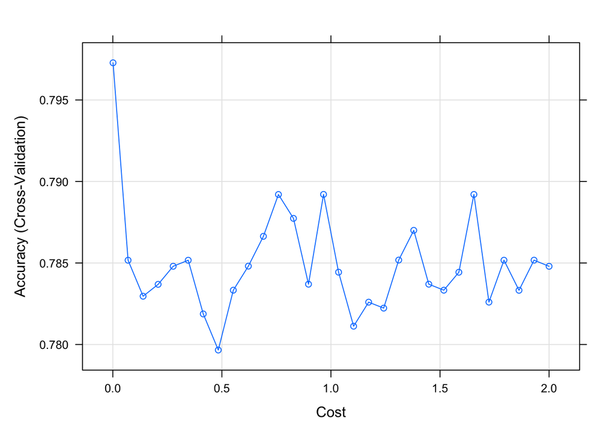

```r
#Visualize accuracy versus values of C
plot(model_svc)
```

```r
#Obtain metrics of accuracy from training
confusionMatrix(model_svc)
```

```
## Cross-Validated (10 fold) Confusion Matrix
##
## (entries are percentual average cell counts across resamples)
##
##           Reference
## Prediction    1    2    3
##          1 18.6  5.9  1.2
##          2  5.5 57.2  1.0
##          3  2.1  4.6  3.9
##
##  Accuracy (average) : 0.7973
```

```r
#See information about final model
model_svc$finalModel
```

```
## Support Vector Machine object of class "ksvm"
##
## SV type: C-svc  (classification)
##  parameter : cost C = 0.001
##
## Linear (vanilla) kernel function.
##
## Number of Support Vectors : 4196
##
## Objective Function Value : -1.7784 -1.9285 -1.5324
## Training error : 0.2552
```

```r
svm_outcome <- predict(model_svc, df_district_train, type = "raw")
confusionMatrix(svm_outcome, df_district_train$q85)
```

```
## Confusion Matrix and Statistics
##
##           Reference
## Prediction    1    2    3
##          1  508  161   29
##          2  151 1557   27
##          3   54  125  111
##
## Overall Statistics
##
##                Accuracy : 0.7991
##                  95% CI : (0.7836, 0.814)
##     No Information Rate : 0.6768
##     P-Value [Acc > NIR] : < 2.2e-16
##
##                   Kappa : 0.5943
##
##  Mcnemar's Test P-Value : 2.562e-15
##
## Statistics by Class:
##
##                      Class: 1 Class: 2 Class: 3
## Sensitivity            0.7125   0.8448  0.66467
## Specificity            0.9055   0.7977  0.92997
## Pos Pred Value         0.7278   0.8974  0.38276
## Neg Pred Value         0.8988   0.7105  0.97698
## Prevalence             0.2618   0.6768  0.06133
## Detection Rate         0.1866   0.5718  0.04076
## Detection Prevalence   0.2563   0.6372  0.10650
## Balanced Accuracy      0.8090   0.8213  0.79732
```

## fit the lasso regression

```r
set.seed(123)
#Create grid to search lambda
lambda <- 10^seq(-3,3, length = 100)

# Specify training control
train_control_lasso <- trainControl(method = "cv", number = 10)

model_lasso = train(q85 ~.,
                    df_district_train,
                    method = "glmnet",
                    trControl = train_control_lasso,
                    tuneGrid = expand.grid(alpha = 1, lambda = lambda))

summary(model_lasso)
```

```
##             Length Class      Mode
## a0          267    -none-     numeric
## beta          3    -none-     list
## dfmat       267    -none-     numeric
## df           89    -none-     numeric
## dim           2    -none-     numeric
## lambda       89    -none-     numeric
## dev.ratio    89    -none-     numeric
## nulldev       1    -none-     numeric
## npasses       1    -none-     numeric
## jerr          1    -none-     numeric
## offset        1    -none-     logical
## classnames    3    -none-     character
## grouped       1    -none-     logical
## call          5    -none-     call
## nobs          1    -none-     numeric
## lambdaOpt     1    -none-     numeric
## xNames       76    -none-     character
## problemType   1    -none-     character
## tuneValue     2    data.frame list
## obsLevels     3    -none-     character
## param         0    -none-     list
```

```r
model_lasso$bestTune
```

```
##    alpha     lambda
## 20     1 0.01417474
```

```r
model_lasso$results
```

```
##     alpha       lambda  Accuracy     Kappa  AccuracySD    KappaSD
## 1       1 1.000000e-03 0.7991357 0.5565832 0.020613664 0.04245302
## 2       1 1.149757e-03 0.7991384 0.5566628 0.021582850 0.04376406
## 3       1 1.321941e-03 0.7991411 0.5557104 0.021128661 0.04293528
## 4       1 1.519911e-03 0.7987721 0.5542629 0.019888021 0.04137988
## 5       1 1.747528e-03 0.7991371 0.5541075 0.019168699 0.04169318
## 6       1 2.009233e-03 0.8006077 0.5565878 0.019150920 0.04367421
## 7       1 2.310130e-03 0.8020742 0.5602604 0.018334897 0.04040247
## 8       1 2.656088e-03 0.8024459 0.5608708 0.017808620 0.03922915
## 9       1 3.053856e-03 0.8009794 0.5582742 0.018596026 0.03987841
## 10      1 3.511192e-03 0.7998764 0.5544895 0.018488893 0.03979896
## 11      1 4.037017e-03 0.8013484 0.5570399 0.017292655 0.03730644
## 12      1 4.641589e-03 0.8020850 0.5571292 0.019155874 0.04159526
## 13      1 5.336699e-03 0.8017201 0.5561348 0.019089067 0.04101911
## 14      1 6.135907e-03 0.8009767 0.5512554 0.016213628 0.03621732
```

[output cut: 86 more lines]

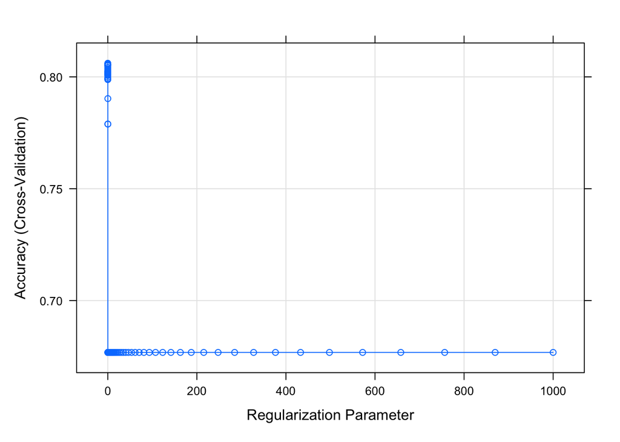

```r
#Visualize accuracy versus values of C
plot(model_lasso)
```

```r
#Obtain metrics of accuracy from training
confusionMatrix(model_lasso)
```

```
## Cross-Validated (10 fold) Confusion Matrix
##
## (entries are percentual average cell counts across resamples)
##
##           Reference
## Prediction    1    2    3
##          1 18.8  5.9  1.1
##          2  7.4 61.7  4.9
##          3  0.0  0.0  0.1
##
##  Accuracy (average) : 0.8061
```

```r
varImp(model_lasso)
```

```
## glmnet variable importance
##
##   variables are sorted by maximum importance across the classes
##   only 20 most important variables shown (out of 76)
##
##                 1        2     3
## q842      21.9449 100.0000  0.00
## q843      63.4116   0.0000 47.23
## q533      22.9494   0.0000  0.00
## qnothhpl2 19.6918   0.0000  0.00
## q178       0.0000  15.7429  0.00
## q652      15.0689   0.0000  0.00
## q895       0.0000   3.3982  0.00
## race42     3.3929   0.0000  0.00
## q632       0.0000   2.2172  0.00
## q492       1.8942   0.0000  0.00
## grade3     1.8571   0.0000  0.00
## age6       0.9011   0.0000  0.00
## sex2       0.8916   0.0000  0.00
## grade2     0.7434   0.0000  0.00
## age4       0.0000   0.5313  0.00
## q873       0.0000   0.3210  0.00
## q474       0.0000   0.0000  0.00
## q173       0.0000   0.0000  0.00
## q174       0.0000   0.0000  0.00
## age7       0.0000   0.0000  0.00
```

```r
lasso_outcome <- predict(model_lasso, df_district_train, type = "raw")
confusionMatrix(lasso_outcome, df_district_train$q85)
```

```
## Confusion Matrix and Statistics
##
##           Reference
## Prediction    1    2    3
##          1  513  162   31
##          2  200 1680  134
##          3    0    1    2
##
## Overall Statistics
##
##                Accuracy : 0.8061
##                  95% CI : (0.7907, 0.8208)
##     No Information Rate : 0.6768
##     P-Value [Acc > NIR] : < 2.2e-16
##
##                   Kappa : 0.5506
##
##  Mcnemar's Test P-Value : < 2.2e-16
##
## Statistics by Class:
##
##                      Class: 1 Class: 2  Class: 3
## Sensitivity            0.7195   0.9116 0.0119760
## Specificity            0.9040   0.6205 0.9996088
## Pos Pred Value         0.7266   0.8342 0.6666667
## Neg Pred Value         0.9008   0.7701 0.9393382
## Prevalence             0.2618   0.6768 0.0613294
## Detection Rate         0.1884   0.6170 0.0007345
## Detection Prevalence   0.2593   0.7396 0.0011017
## Balanced Accuracy      0.8117   0.7660 0.5057924
```

## fit the ridge regression

```r
set.seed(123)
#Create grid to search lambda
lambda <- 10^seq(-3,3, length = 100)

# Specify training control
train_control_ridge <- trainControl(method = "cv", number = 10)

model_ridge = train(q85 ~.,
                    df_district_train,
                    method = "glmnet",
                    trControl = train_control_ridge,
                    tuneGrid = expand.grid(alpha = 0, lambda = lambda))

summary(model_ridge)
```

```
##             Length Class      Mode
## a0          300    -none-     numeric
## beta          3    -none-     list
## dfmat       300    -none-     numeric
## df          100    -none-     numeric
## dim           2    -none-     numeric
## lambda      100    -none-     numeric
## dev.ratio   100    -none-     numeric
## nulldev       1    -none-     numeric
## npasses       1    -none-     numeric
## jerr          1    -none-     numeric
## offset        1    -none-     logical
## classnames    3    -none-     character
## grouped       1    -none-     logical
## call          5    -none-     call
## nobs          1    -none-     numeric
## lambdaOpt     1    -none-     numeric
## xNames       76    -none-     character
## problemType   1    -none-     character
## tuneValue     2    data.frame list
## obsLevels     3    -none-     character
## param         0    -none-     list
```

```r
model_ridge$bestTune
```

```
##    alpha     lambda
## 28     0 0.04328761
```

```r
model_ridge$results
```

```
##     alpha       lambda  Accuracy       Kappa  AccuracySD     KappaSD
## 1       0 1.000000e-03 0.7954592 0.536884671 0.016543776 0.033886435
## 2       0 1.149757e-03 0.7954592 0.536884671 0.016543776 0.033886435
## 3       0 1.321941e-03 0.7954592 0.536884671 0.016543776 0.033886435
## 4       0 1.519911e-03 0.7954592 0.536884671 0.016543776 0.033886435
## 5       0 1.747528e-03 0.7954592 0.536884671 0.016543776 0.033886435
## 6       0 2.009233e-03 0.7954592 0.536884671 0.016543776 0.033886435
## 7       0 2.310130e-03 0.7954592 0.536884671 0.016543776 0.033886435
## 8       0 2.656088e-03 0.7954592 0.536884671 0.016543776 0.033886435
## 9       0 3.053856e-03 0.7954592 0.536884671 0.016543776 0.033886435
## 10      0 3.511192e-03 0.7954592 0.536884671 0.016543776 0.033886435
## 11      0 4.037017e-03 0.7954592 0.536884671 0.016543776 0.033886435
## 12      0 4.641589e-03 0.7954592 0.536884671 0.016543776 0.033886435
## 13      0 5.336699e-03 0.7954592 0.536884671 0.016543776 0.033886435
## 14      0 6.135907e-03 0.7954592 0.536884671 0.016543776 0.033886435
```

[output cut: 86 more lines]

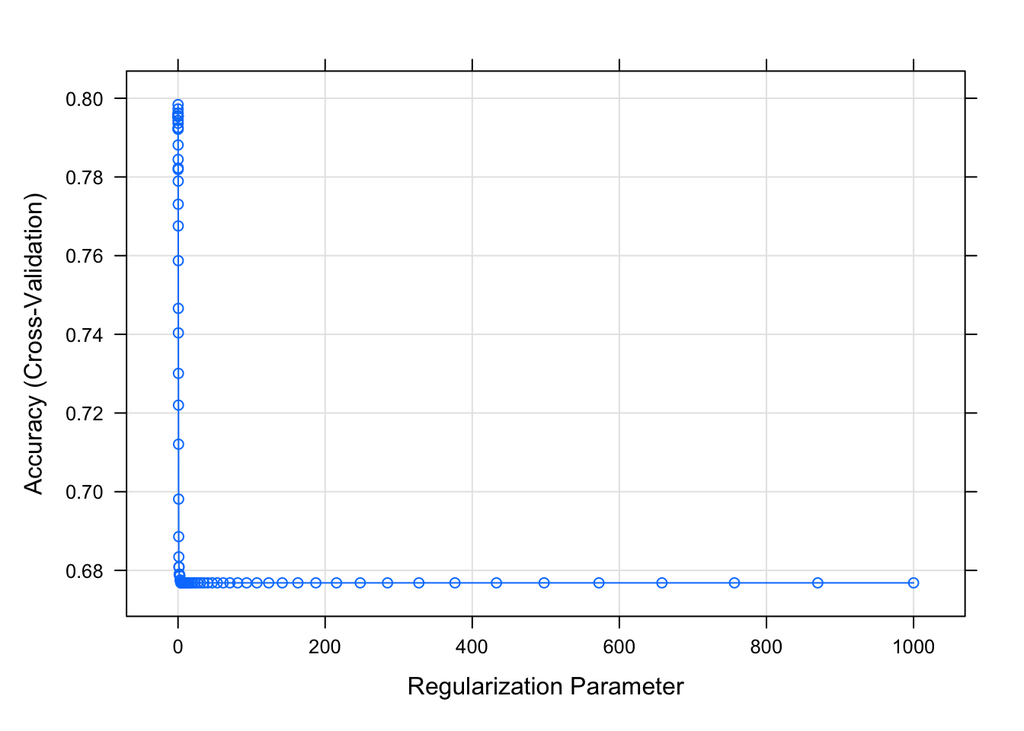

```r
#Visualize accuracy versus values of C
plot(model_ridge)
```

```r
#Obtain metrics of accuracy from training
confusionMatrix(model_ridge)
```

```
## Cross-Validated (10 fold) Confusion Matrix
##
## (entries are percentual average cell counts across resamples)
##
##           Reference
## Prediction    1    2    3
##          1 17.9  5.8  1.2
##          2  8.0 61.2  4.2
##          3  0.3  0.7  0.7
##
##  Accuracy (average) : 0.7984
```

```r
varImp(model_ridge)
```

```
## glmnet variable importance
##
##   variables are sorted by maximum importance across the classes
##   only 20 most important variables shown (out of 76)
##
##           1       2      3
## q842 77.811 100.000 22.189
## q843 88.543   3.322 91.865
## q533 86.343  61.866 24.478
## q524 37.680  64.838 27.158
## q177 60.884  31.258 29.627
## q535 57.350  41.789 15.561
## q523 55.304  25.268 30.036
## q522  8.744  54.439 45.695
## q416 25.932  24.725 50.657
## q417 48.660  18.273 30.387
## q532 30.878  14.753 45.631
## q178 23.397  42.625 19.228
## q505 42.291  19.626 22.665
## q506 38.510   8.891 29.618
## q534 30.802  34.257  3.455
## q215  5.298  30.290 24.992
## q536 14.086  14.694 28.780
## q895  5.947  27.130 21.182
## q175 13.177  13.866 27.042
## q496 17.042   9.946 26.988
```

```r
ridge_outcome <- predict(model_ridge, df_district_train, type = "raw")
confusionMatrix(ridge_outcome, df_district_train$q85)
```

```
## Confusion Matrix and Statistics
##
##           Reference
## Prediction    1    2    3
##          1  494  146   32
##          2  211 1685  100
##          3    8   12   35
##
## Overall Statistics
##
##                Accuracy : 0.8131
##                  95% CI : (0.7979, 0.8276)
##     No Information Rate : 0.6768
##     P-Value [Acc > NIR] : < 2.2e-16
##
##                   Kappa : 0.5732
##
##  Mcnemar's Test P-Value : < 2.2e-16
##
## Statistics by Class:
##
##                      Class: 1 Class: 2 Class: 3
## Sensitivity            0.6928   0.9143  0.20958
## Specificity            0.9114   0.6466  0.99218
## Pos Pred Value         0.7351   0.8442  0.63636
## Neg Pred Value         0.8932   0.7827  0.95052
## Prevalence             0.2618   0.6768  0.06133
## Detection Rate         0.1814   0.6188  0.01285
## Detection Prevalence   0.2468   0.7330  0.02020
## Balanced Accuracy      0.8021   0.7804  0.60088
```

# fit the Elastic Net method

```r
# model 2, chooses alpha and lambda via cross-validation using all of the features - Elastic Net method
set.seed(123)

# Construct k-folds in your data
trcontrol = trainControl(method = "cv", number = 10, sampling = "up")

# model 2 fit
model_elastic_net <- train(q85 ~.,
                     data = df_district_train,
                     method = "glmnet",
                     trControl = trcontrol,
                     preProc=c("center", "scale"),
                     tuneLength = 10, metric = "Accuracy"
  )
# Print the values of alpha and lambda that gave best prediction
model_elastic_net$bestTune
```

```
##    alpha    lambda
## 10   0.1 0.2532097
```

```r
# Print all of the options examined
model_elastic_net$results
```

```
##     alpha       lambda  Accuracy     Kappa AccuracySD    KappaSD
## 1     0.1 0.0001351304 0.7701036 0.5490646 0.02377338 0.04185913
## 2     0.1 0.0003121687 0.7701036 0.5490646 0.02377338 0.04185913
## 3     0.1 0.0007211502 0.7715728 0.5513956 0.02290313 0.04049577
## 4     0.1 0.0016659506 0.7748830 0.5567141 0.01991533 0.03604794
## 5     0.1 0.0038485619 0.7763536 0.5580429 0.01946687 0.03581798
## 6     0.1 0.0088906771 0.7778215 0.5602516 0.01884416 0.03438093
## 7     0.1 0.0205386173 0.7873736 0.5753283 0.01732600 0.03155934
## 8     0.1 0.0474468699 0.7939778 0.5861249 0.01366273 0.02507985
## 9     0.1 0.1096084234 0.7965473 0.5893159 0.01541346 0.02802322
## 10    0.1 0.2532096742 0.8002211 0.5955732 0.01318605 0.02441353
## 11    0.2 0.0001351304 0.7748830 0.5554239 0.01708909 0.03131779
## 12    0.2 0.0003121687 0.7748830 0.5554239 0.01708909 0.03131779
## 13    0.2 0.0007211502 0.7745140 0.5551499 0.01712700 0.03155056
## 14    0.2 0.0016659506 0.7752520 0.5561049 0.01730394 0.03125001
```

[output cut: 86 more lines]

```r
# Model coefficients
coef(model_elastic_net$finalModel, model_elastic_net$bestTune$lambda)
```

```
## $`1`
## 77 x 1 sparse Matrix of class "dgCMatrix"
##                         1
## (Intercept)  0.0471542883
## age2         .
## age3        -0.0029573180
## age4         .
## age5         .
## age6         0.0009702804
## age7         .
## sex2        -0.0459616000
## grade2      -0.0078479941
## grade3       .
## grade4       0.0008127637
## race42       0.0366996756
## race43       .
## race44       .
## bmi          .
## qnothhpl2   -0.0724678915
## q172         .
## q173         .
## q174         .
## q175         .
## q176         .
## q177         .
## q178         .
## q212         .
## q213         .
## q214         .
## q215         .
## q216         .
## q232         .
## q262         .
## q302         .
## q412         .
## q413         .
## q414         .
## q415         .
## q416         .
## q417         .
```

[output cut: 187 more lines]

```
## q632         .
## q633         .
## q652         0.003688746
## q653         .
## q654        -0.011165643
## q842        -0.125937081
## q843         0.450947409
## q872         .
## q873         .
## q892         .
## q893         0.022279183
## q894         .
## q895         .
## q896         .
## q897         .
```

```r
# visualization and accuracy
varImp(model_elastic_net)
```

```
## glmnet variable importance
##
##   variables are sorted by maximum importance across the classes
##   only 20 most important variables shown (out of 76)
##
##                 1       2       3
## q842      50.1404 100.000 26.4879
## q843      52.0997  19.375 94.8462
## q652      15.5130   0.000  0.7758
## qnothhpl2 15.2419   5.554  0.0000
## sex2       9.6669   0.000  0.0000
## race42     7.7189   0.000  0.0000
## q893       0.0000   0.000  4.6859
## race43     0.0000   0.000  2.7952
## q654       1.8397   0.000  2.3484
## q632       0.6594   1.969  0.0000
## q633       0.6860   1.958  0.0000
## q302       0.0000   0.000  1.9393
## grade2     1.6506   0.000  0.0000
## q503       1.2526   0.000  0.0000
## q653       1.0557   0.000  0.0000
## q533       0.8968   0.000  0.0000
## age3       0.6220   0.000  0.0000
## q532       0.0000   0.000  0.5721
## grade4     0.1709   0.000  0.5581
## age6       0.2041   0.000  0.0000
```

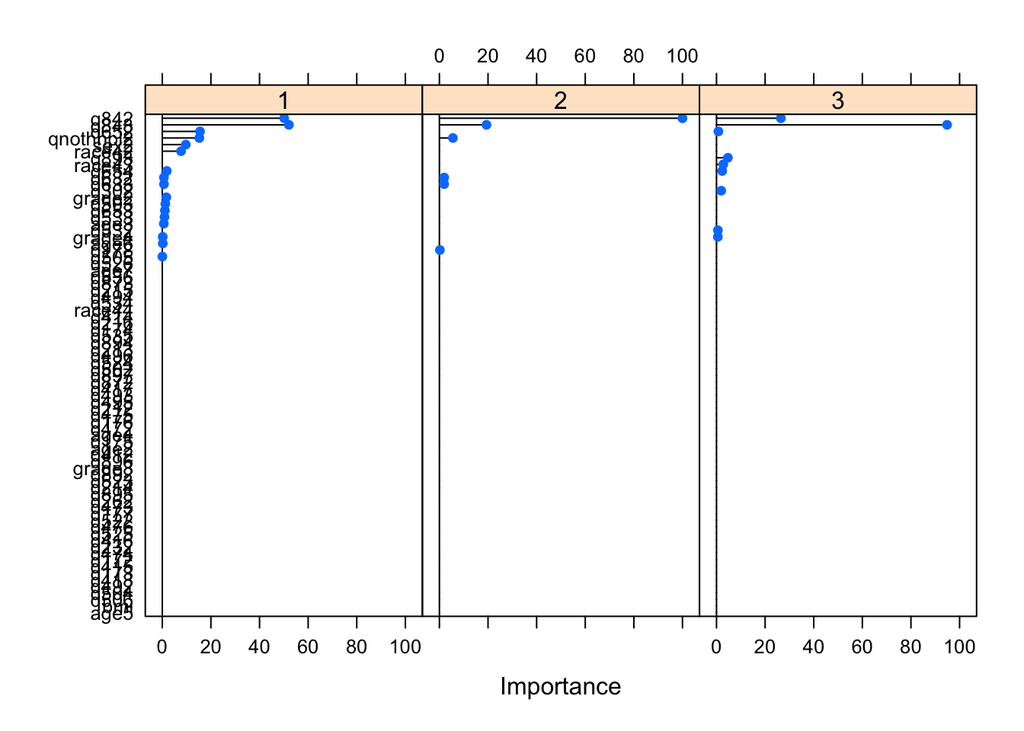

```r
plot(varImp(model_elastic_net))
```

```r
confusionMatrix(model_elastic_net)
```

```
## Cross-Validated (10 fold) Confusion Matrix
##
## (entries are percentual average cell counts across resamples)
##
##           Reference
## Prediction    1    2    3
##          1 18.8  5.9  1.1
##          2  5.5 57.3  1.0
##          3  1.8  4.5  4.0
##
##  Accuracy (average) : 0.8002
```

```r
elastic_net_outcome <- predict(model_elastic_net, df_district_train, type = "raw")
confusionMatrix(elastic_net_outcome, df_district_train$q85)
```

```
## Confusion Matrix and Statistics
##
##           Reference
## Prediction    1    2    3
##          1  512  162   31
##          2  151 1559   28
##          3   50  122  108
##
## Overall Statistics
##
##                Accuracy : 0.8002
##                  95% CI : (0.7847, 0.8151)
##     No Information Rate : 0.6768
##     P-Value [Acc > NIR] : < 2.2e-16
##
##                   Kappa : 0.5955
##
##  Mcnemar's Test P-Value : 9.283e-14
##
## Statistics by Class:
##
##                      Class: 1 Class: 2 Class: 3
## Sensitivity            0.7181   0.8459  0.64671
## Specificity            0.9040   0.7966  0.93271
## Pos Pred Value         0.7262   0.8970  0.38571
## Neg Pred Value         0.9004   0.7117  0.97585
## Prevalence             0.2618   0.6768  0.06133
## Detection Rate         0.1880   0.5725  0.03966
## Detection Prevalence   0.2589   0.6383  0.10283
## Balanced Accuracy      0.8110   0.8212  0.78971
```

# fit the classfication Tree model

```r
set.seed(123)

#Using 10-fold cross-validation to train model
train_control_tree <- trainControl(method = "cv", number = 10, sampling = "down")

#Create sequence of cp parameters to try
grid_tree <- expand.grid(cp = seq(0.001, 0.3, by = 0.01))

#Using rpart method to generate regression tree, using all variables in dataset to predict life expectancy
model_tree <- train(q85 ~ . ,
                     data = df_district_train,
                     method = "rpart",
                     trControl = train_control_tree,
                     tuneGrid = grid_tree)

model_tree$bestTune
```

```
##       cp
## 26 0.251
```

```r
model_tree$results
```

[output not shown]

[output cut: 16 more lines]

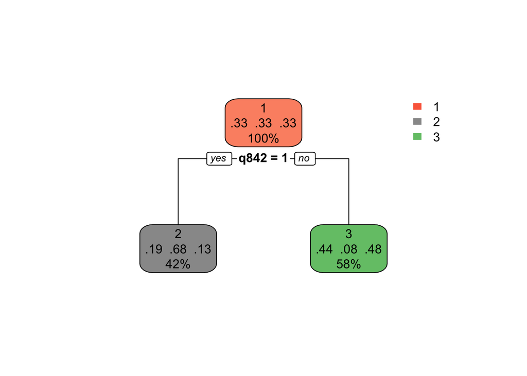

```r
#Can use rpart.plot function to visualize tree
rpart.plot(model_tree$finalModel)
```

```r
#Note you can obtain variable importance on the final model within training data
varImp(model_tree)
```

```
## rpart variable importance
##
##   only 20 most important variables shown (out of 76)
##
##           Overall
## q842      100.000
## q843       90.714
## q652        8.210
## q653        6.868
## qnothhpl2   6.531
## q895        0.000
## q524        0.000
## q213        0.000
## q897        0.000
## q172        0.000
## q413        0.000
## age2        0.000
## q494        0.000
## q417        0.000
## race43      0.000
## age7        0.000
## q534        0.000
## bmi         0.000
## q474        0.000
## q416        0.000
```

```r
tree_outcome <- predict(model_tree, df_district_train, type = "raw")
confusionMatrix(tree_outcome, df_district_train$q85)
```

```
## Confusion Matrix and Statistics
##
##           Reference
## Prediction    1    2    3
##          1    0    0    0
##          2  151 1559   28
##          3  562  284  139
##
## Overall Statistics
##
##                Accuracy : 0.6236
##                  95% CI : (0.6051, 0.6418)
##     No Information Rate : 0.6768
##     P-Value [Acc > NIR] : 1
##
##                   Kappa : 0.3104
##
##  Mcnemar's Test P-Value : <2e-16
##
## Statistics by Class:
##
##                      Class: 1 Class: 2 Class: 3
## Sensitivity            0.0000   0.8459  0.83234
## Specificity            1.0000   0.7966  0.66901
## Pos Pred Value            NaN   0.8970  0.14112
## Neg Pred Value         0.7382   0.7117  0.98389
## Prevalence             0.2618   0.6768  0.06133
## Detection Rate         0.0000   0.5725  0.05105
## Detection Prevalence   0.0000   0.6383  0.36173
## Balanced Accuracy      0.5000   0.8212  0.75067
```